# GRF dmin.grf Calibration for ACTG175 Binary Benefit

- Show All Code
- Hide All Code
- View Source

Calibrating to the 12-Confounder ACTG175 DGM

Author

Larry F. León

Published

April 11, 2026

# 1 Purpose

The `grf_dmin_calibration_binary.qmd` document calibrated `dmin.grf` on **synthetic 4-confounder data** and found `dmin.grf = 0.02` achieves strong FPR control. However, the ACTG175 binary benefit scenario uses **12 binary confounders**, which creates substantially more candidate splits for the policy tree and weakens FPR control.

This document calibrates `dmin.grf` directly on the ACTG175 DGM to find the value that balances detection power and FPR control for this specific application.

Current results at `dmin.grf = 0.10` (2,000 sims):

| Metric | FS | GRF |
| --- | --- | --- |
| H1 Detection | 74% | 72% |
| H1 Sensitivity | 0.57 | 0.90 |
| H1 PPV | 0.80 | 0.75 |
| H0 FPR | 4% | 28% |
| θ̂(Q̂) bias | — | 1.8% |

# 2 Data Preparation

```r
library(forestsearch)
library(survival)
library(data.table)
library(ggplot2)
library(gt)
library(doFuture)
library(foreach)

plan(multisession, workers = n_workers)
cat(sprintf("Workers: %d\n", n_workers))
```

```
#> Workers: 115
```

```r
reset_workers <- function(msg = "") {
  if (nzchar(msg)) cat(sprintf("[Resetting workers: %s]\n", msg))
  plan(sequential); gc(verbose = FALSE); Sys.sleep(1)
  plan(multisession, workers = n_workers)
}

t_start <- proc.time()
```

```r
# Replicate ACTG175 data preparation from binary benefit document
actg_df <- subset(speff2trial::ACTG175, arms %in% actg_arms)
actg_df$id <- seq_len(nrow(actg_df))
actg_df$treat_orig <- ifelse(actg_df$arms == actg_treat_arm, 1L, 0L)
actg_df$treat <- 1L - actg_df$treat_orig   # switched for benefit search
actg_df$y_binary <- as.integer(actg_df$cd420 > actg_df$cd40)
actg_df <- actg_df[!is.na(actg_df$cd420), ]

# Discretise covariates
actg_df$z1  <- as.factor(ifelse(actg_df$age > actg_age_cut, 1L, 0L))
actg_df$z2  <- as.factor(ifelse(actg_df$preanti <= actg_preanti_cut, 1L, 0L))
actg_df$z3  <- as.factor(ifelse(actg_df$wtkg <= 75, 1L, 0L))
actg_df$z4  <- as.factor(ifelse(actg_df$karnof <= median(actg_df$karnof), 1L, 0L))
actg_df$z5  <- as.factor(ifelse(actg_df$cd40 <= median(actg_df$cd40), 1L, 0L))
actg_df$z6  <- as.factor(ifelse(actg_df$cd80 <= median(actg_df$cd80), 1L, 0L))
actg_df$z7  <- as.factor(actg_df$hemo)
actg_df$z8  <- as.factor(actg_df$homo)
actg_df$z9  <- as.factor(actg_df$drugs)
actg_df$z10 <- as.factor(actg_df$race)
actg_df$z11 <- as.factor(actg_df$gender)
actg_df$z12 <- as.factor(actg_df$symptom)

actg_df$flag_harm_ref <- as.integer(actg_df$z1 == 1 & actg_df$z2 == 1)
cat(sprintf("N=%d, confounders=%d, Q prevalence=%.1f%%\n",
    nrow(actg_df), length(dgm_factor_vars),
    100 * mean(actg_df$flag_harm_ref)))
```

```
#> N=1083, confounders=12, Q prevalence=35.3%
```

# 3 DGM Construction

```r
# Calibrate H1 DGM
dgm_calibrated <- calibrate_glm_interaction(
  data = actg_df, factor_vars = dgm_factor_vars,
  outcome_var = "y_binary", treatment_var = "treat",
  target_effect = cal_target_or,
  outcome_type = "binary", effect_measure = "OR",
  subgroup_vars = dgm_subgroup_vars,
  subgroup_cuts = dgm_subgroup_cuts,
  k_inter_range = cal_k_grid_range, grid_step = cal_grid_step,
  n_super = dgm_n_super, seed = sim_seed, verbose = TRUE
)
```

```
#> Calibrating: target OR = 2.000
#>   Grid: 0.00 to 3.00 by 0.050 (61 values)
#>   Best: k_inter = 1.150 -> Effect(Q) = 2.0071 (target: 2.000)
#> === generate_glm_dgm() ===
#>   outcome_type:   binary
#>   effect_measure: OR
#>   model:          alt
#>   k_inter:        1.150
#>   k_treat:        1.000
#>   n_super:        5000
#>   n observations: 1083
#>   Dropped single-level factors: z4
#>
#> === Subgroup Definitions ===
#>    z1 == 1
#>     Proportion in subgroup: 0.488
#>    z2 == 1
#>     Proportion in subgroup: 0.75
#>
#> Overall subgroup (all conditions met):
#>   Size: 382 out of 1083
#>   Proportion: 0.353
#>
#> Baseline GLM fit (no interaction):
#>   AIC: 1411.2
#>   Treatment coefficient: -0.4269 (OR = 0.653)
#>   Interaction shift (k_inter): 1.1500
#>
#> === DGM Summary ===
#>   Effect(Q):   2.0071  (OR)
#>   Effect(Qc):  0.6681  (OR)
#>   Effect(ITT): 0.9186  (OR)
#>   Subgroup prevalence: 34.5%
#>
#> Calibration complete: k_inter = 1.150
#>   Effect(Q):   2.0071
#>   Effect(Qc):  0.6681
#>   Effect(ITT): 0.9186
```

```r
cat(sprintf("\nH1 DGM: OR(Q)=%.3f (target %.1f), k_inter=%.2f\n",
    dgm_calibrated$hazard_ratios$harm_subgroup,
    cal_target_or, dgm_calibrated$model_params$k_inter))
```

```
#>
#> H1 DGM: OR(Q)=2.007 (target 2.0), k_inter=1.15
```

```r
# H0 DGM (homogeneous treatment effect)
dgm_null <- generate_glm_dgm(
  data = actg_df, factor_vars = dgm_factor_vars,
  outcome_var = "y_binary", treatment_var = "treat",
  outcome_type = "binary", effect_measure = "OR",
  subgroup_vars = dgm_subgroup_vars,
  subgroup_cuts = dgm_subgroup_cuts,
  model = "null", k_treat = 1,
  n_super = dgm_n_super, seed = sim_seed
)

cat(sprintf("H0 DGM: OR(ITT)=%.3f\n",
    dgm_null$hazard_ratios$overall))
```

```
#> H0 DGM: OR(ITT)=0.668
```

# 4 dmin.grf Sweep

For each value in the grid, run 100 simulations under both H1 and H0. Each simulation calls `grf.subg.harm.glm()` directly with 12 confounders at N = 1000.

```r
run_dmin_eval <- function(dgm, nsims, dmin_val) {
  results_raw <- foreach(
    i = seq_len(nsims),
    .errorhandling = "pass",
    .options.future = list(
      packages = c("forestsearch", "survival", "data.table"),
      seed = TRUE
    )
  ) %dofuture% {
    sim_df <- simulate_from_glm_dgm(dgm, n = sim_n,
                                     seed = sim_seed + i * 1000L)
    res <- tryCatch(
      grf.subg.harm.glm(
        data = sim_df, confounders.name = dgm_factor_vars,
        outcome.name = "y_sim", treat.name = "treat_sim",
        id.name = "id", outcome_type = "binary",
        adverse_outcome = TRUE,
        n.min = 40L, dmin.grf = dmin_val, maxdepth = grf_maxdepth,
        RCT = TRUE, sg.criterion = grf_sg_criterion,
        seedit = 42L, verbose = FALSE
      ),
      error = function(e) NULL
    )

    detected <- !is.null(res) && !is.null(res$sg.harm.id) &&
      length(res$sg.harm.id) > 0 && !all(is.na(res$sg.harm.id))

    # Classification metrics (only if detected)
    sens <- ppv <- n_H <- NA_real_
    if (detected && !is.null(res$data) &&
        "treat.recommend" %in% names(res$data)) {
      in_H <- res$data$treat.recommend == 0
      true_Q <- sim_df$flag_harm
      n_H <- sum(in_H)
      tp <- sum(in_H & true_Q == 1)
      fp <- sum(in_H & true_Q == 0)
      fn <- sum(!in_H & true_Q == 1)
      sens <- tp / max(tp + fn, 1)
      ppv  <- tp / max(tp + fp, 1)
    }

    list(detected = detected, sens = sens, ppv = ppv, n_H = n_H)
  }

  is_err <- vapply(results_raw, inherits, logical(1), "error")
  good <- results_raw[!is_err]

  det_vec  <- vapply(good, function(x) x$detected, logical(1))
  sens_vec <- vapply(good, function(x) x$sens, numeric(1))
  ppv_vec  <- vapply(good, function(x) x$ppv, numeric(1))
  nH_vec   <- vapply(good, function(x) x$n_H, numeric(1))

  list(
    det_pct    = 100 * mean(det_vec),
    mean_sens  = mean(sens_vec[det_vec & !is.na(sens_vec)]),
    mean_ppv   = mean(ppv_vec[det_vec & !is.na(ppv_vec)]),
    mean_nH    = mean(nH_vec[det_vec & !is.na(nH_vec)]),
    n_errors   = sum(is_err)
  )
}
```

```r
cat(sprintf("dmin.grf grid: %s\n", paste(dmin_grid, collapse = ", ")))
```

```
#> dmin.grf grid: 0, 0.02, 0.05, 0.08, 0.1, 0.12, 0.15, 0.2, 0.25, 0.3
```

```r
cat(sprintf("Sims per point: %d alt + %d null, N=%d\n", nsims, nsims, sim_n))
```

```
#> Sims per point: 100 alt + 100 null, N=1000
```

```r
cat(sprintf("Confounders: %d\n\n", length(dgm_factor_vars)))
```

```
#> Confounders: 12
```

```r
sweep_results <- data.frame(
  dmin = numeric(0), Det_H1 = numeric(0), FPR_H0 = numeric(0),
  Sens_H1 = numeric(0), PPV_H1 = numeric(0),
  Avg_nH_H1 = numeric(0),
  Sens_H0 = numeric(0), PPV_H0 = numeric(0),
  stringsAsFactors = FALSE
)

for (dmin_val in dmin_grid) {
  cat(sprintf("--- dmin = %.2f ---\n", dmin_val))

  if (dmin_val == dmin_grid[1] || dmin_val == 0.15) {
    reset_workers(sprintf("dmin=%.2f", dmin_val))
  }

  # H1
  t0 <- proc.time()[3]
  h1 <- run_dmin_eval(dgm_calibrated, nsims, dmin_val)
  t_h1 <- proc.time()[3] - t0

  # H0
  t0 <- proc.time()[3]
  h0 <- run_dmin_eval(dgm_null, nsims, dmin_val)
  t_h0 <- proc.time()[3] - t0

  sweep_results[nrow(sweep_results) + 1, ] <- data.frame(
    dmin = dmin_val,
    Det_H1 = round(h1$det_pct, 1),
    FPR_H0 = round(h0$det_pct, 1),
    Sens_H1 = round(h1$mean_sens, 3),
    PPV_H1 = round(h1$mean_ppv, 3),
    Avg_nH_H1 = round(h1$mean_nH, 0),
    Sens_H0 = round(h0$mean_sens, 3),
    PPV_H0 = round(h0$mean_ppv, 3),
    stringsAsFactors = FALSE
  )

  flag <- if (h1$det_pct >= target_det && h0$det_pct <= target_fpr) " ***" else ""
  cat(sprintf("  H1: Det=%.0f%%, Sens=%.2f, PPV=%.2f, avg|H|=%.0f (%.0fs)\n",
      h1$det_pct, h1$mean_sens, h1$mean_ppv, h1$mean_nH, t_h1))
  cat(sprintf("  H0: FPR=%.0f%%, Sens=%.2f, PPV=%.2f (%.0fs)%s\n\n",
      h0$det_pct, h0$mean_sens, h0$mean_ppv, t_h0, flag))
}
```

```
#> --- dmin = 0.00 ---
#> [Resetting workers: dmin=0.00]
#>   H1: Det=100%, Sens=0.92, PPV=0.73, avg|H|=436 (118s)
#>   H0: FPR=90%, Sens=0.21, PPV=0.34 (9s)
#>
#> --- dmin = 0.02 ---
#>   H1: Det=100%, Sens=0.92, PPV=0.73, avg|H|=436 (3s)
#>   H0: FPR=88%, Sens=0.20, PPV=0.34 (3s)
#>
#> --- dmin = 0.05 ---
#>   H1: Det=98%, Sens=0.92, PPV=0.73, avg|H|=438 (3s)
#>   H0: FPR=71%, Sens=0.16, PPV=0.33 (3s)
#>
#> --- dmin = 0.08 ---
#>   H1: Det=87%, Sens=0.93, PPV=0.75, avg|H|=431 (3s)
#>   H0: FPR=46%, Sens=0.14, PPV=0.31 (3s)
#>
#> --- dmin = 0.10 ---
#>   H1: Det=72%, Sens=0.92, PPV=0.76, avg|H|=420 (3s)
#>   H0: FPR=33%, Sens=0.11, PPV=0.29 (3s)
#>
#> --- dmin = 0.12 ---
#>   H1: Det=54%, Sens=0.94, PPV=0.78, avg|H|=414 (3s)
#>   H0: FPR=20%, Sens=0.09, PPV=0.29 (3s)
#>
#> --- dmin = 0.15 ---
#> [Resetting workers: dmin=0.15]
#>   H1: Det=28%, Sens=0.94, PPV=0.81, avg|H|=396 (118s)
#>   H0: FPR=9%, Sens=0.06, PPV=0.33 (9s)
#>
#> --- dmin = 0.20 ---
#>   H1: Det=3%, Sens=0.68, PPV=0.69, avg|H|=271 (3s)
#>   H0: FPR=4%, Sens=0.07, PPV=0.36 (3s)
#>
#> --- dmin = 0.25 ---
#>   H1: Det=0%, Sens=NaN, PPV=NaN, avg|H|=NaN (3s)
#>   H0: FPR=3%, Sens=0.09, PPV=0.42 (3s)
#>
#> --- dmin = 0.30 ---
#>   H1: Det=0%, Sens=NaN, PPV=NaN, avg|H|=NaN (3s)
#>   H0: FPR=0%, Sens=NaN, PPV=NaN (3s)
```

```r
plan(sequential)
```

# 5 Results

## 5.1 Full Results Table

```r
sweep_results$Pass <- sweep_results$Det_H1 >= target_det &
                      sweep_results$FPR_H0 <= target_fpr

sweep_results |>
  gt::gt() |>
  gt::tab_header(
    title = "ACTG175 Binary Benefit: dmin.grf Calibration",
    subtitle = sprintf(
      "%d alt + %d null sims, N=%d, 12 confounders | Target: Det >= %d%%, FPR <= %d%%",
      nsims, nsims, sim_n, target_det, target_fpr)
  ) |>
  gt::cols_label(
    dmin = "dmin.grf",
    Det_H1 = "Det (%)",
    FPR_H0 = "FPR (%)",
    Sens_H1 = "Sens (H1)",
    PPV_H1 = "PPV (H1)",
    Avg_nH_H1 = "Avg |Ĥ| (H1)",
    Sens_H0 = "Sens (H0)",
    PPV_H0 = "PPV (H0)"
  ) |>
  gt::tab_style(
    style = gt::cell_fill(color = "#c8e6c9"),
    locations = gt::cells_body(rows = Pass == TRUE)
  ) |>
  gt::tab_style(
    style = gt::cell_fill(color = "#fff9c4"),
    locations = gt::cells_body(
      rows = Det_H1 >= target_det & FPR_H0 <= 25 & !Pass)
  ) |>
  gt::cols_hide(columns = "Pass") |>
  gt::tab_footnote(
    footnote = "Green = meets both targets. Yellow = near-miss (FPR <= 25%)."
  )
```

ACTG175 Binary Benefit: dmin.grf Calibration

100 alt + 100 null sims, N=1000, 12 confounders | Target: Det >= 50%, FPR <= 15%

| dmin.grf | Det (%) | FPR (%) | Sens (H1) | PPV (H1) | Avg \|Ĥ\| (H1) | Sens (H0) | PPV (H0) |
| --- | --- | --- | --- | --- | --- | --- | --- |
| 0.00 | 100 | 90 | 0.920 | 0.735 | 436 | 0.207 | 0.342 |
| 0.02 | 100 | 88 | 0.920 | 0.735 | 436 | 0.198 | 0.336 |
| 0.05 | 98 | 71 | 0.918 | 0.732 | 438 | 0.165 | 0.329 |
| 0.08 | 87 | 46 | 0.929 | 0.752 | 431 | 0.144 | 0.314 |
| 0.10 | 72 | 33 | 0.916 | 0.759 | 420 | 0.114 | 0.294 |
| 0.12 | 54 | 20 | 0.939 | 0.781 | 414 | 0.090 | 0.290 |
| 0.15 | 28 | 9 | 0.938 | 0.806 | 396 | 0.065 | 0.330 |
| 0.20 | 3 | 4 | 0.683 | 0.693 | 271 | 0.073 | 0.355 |
| 0.25 | 0 | 3 | NaN | NaN | NaN | 0.087 | 0.424 |
| 0.30 | 0 | 0 | NaN | NaN | NaN | NaN | NaN |

Green = meets both targets. Yellow = near-miss (FPR <= 25%).

## 5.2 Detection vs FPR Tradeoff

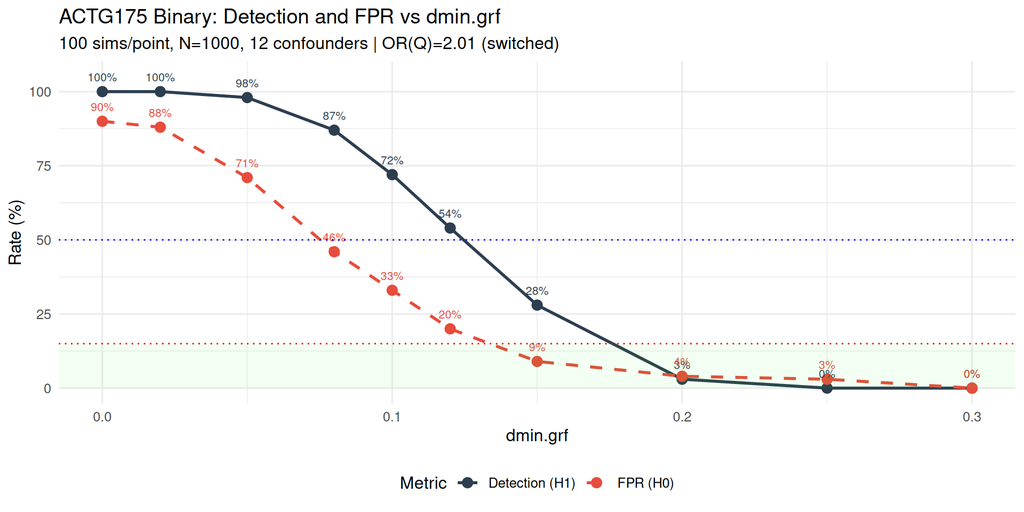

Detection and FPR as a function of dmin.grf for the ACTG175 12-confounder DGM.

```r
if (nrow(sweep_results) > 0) {
  plot_df <- rbind(
    transform(sweep_results, Metric = "Detection (H1)", Rate = Det_H1),
    transform(sweep_results, Metric = "FPR (H0)", Rate = FPR_H0)
  )

  ggplot(plot_df, aes(x = dmin, y = Rate, colour = Metric, linetype = Metric)) +
    geom_line(linewidth = 1) +
    geom_point(size = 3) +
    geom_text(aes(label = sprintf("%.0f%%", Rate)), vjust = -1.2, size = 2.8,
              show.legend = FALSE) +
    geom_hline(yintercept = target_fpr, linetype = "dotted",
               colour = "red", linewidth = 0.5) +
    geom_hline(yintercept = target_det, linetype = "dotted",
               colour = "blue", linewidth = 0.5) +
    annotate("rect", xmin = -Inf, xmax = Inf,
             ymin = 0, ymax = target_fpr,
             alpha = 0.05, fill = "green") +
    scale_colour_manual(values = c(
      "Detection (H1)" = "#2c3e50", "FPR (H0)" = "#e74c3c")) +
    scale_linetype_manual(values = c(
      "Detection (H1)" = "solid", "FPR (H0)" = "dashed")) +
    labs(
      x = "dmin.grf",
      y = "Rate (%)",
      title = "ACTG175 Binary: Detection and FPR vs dmin.grf",
      subtitle = sprintf(
        "%d sims/point, N=%d, 12 confounders | OR(Q)=%.2f (switched)",
        nsims, sim_n, dgm_calibrated$hazard_ratios$harm_subgroup)
    ) +
    coord_cartesian(ylim = c(0, 105)) +
    theme_minimal(base_size = 12) +
    theme(legend.position = "bottom")
}
```

## 5.3 Sensitivity and PPV vs dmin.grf

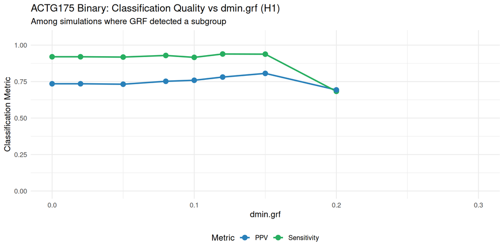

Classification quality (among detections) as a function of dmin.grf.

```r
if (nrow(sweep_results) > 0) {
  cls_df <- rbind(
    data.frame(dmin = sweep_results$dmin,
               Metric = "Sensitivity", Value = sweep_results$Sens_H1),
    data.frame(dmin = sweep_results$dmin,
               Metric = "PPV", Value = sweep_results$PPV_H1)
  )

  ggplot(cls_df, aes(x = dmin, y = Value, colour = Metric)) +
    geom_line(linewidth = 1) +
    geom_point(size = 3) +
    labs(
      x = "dmin.grf",
      y = "Classification Metric",
      title = "ACTG175 Binary: Classification Quality vs dmin.grf (H1)",
      subtitle = "Among simulations where GRF detected a subgroup"
    ) +
    scale_colour_manual(values = c(
      Sensitivity = "#27ae60", PPV = "#2980b9")) +
    coord_cartesian(ylim = c(0, 1.05)) +
    theme_minimal(base_size = 12) +
    theme(legend.position = "bottom")
}
```

## 5.4 Subgroup Size vs dmin.grf

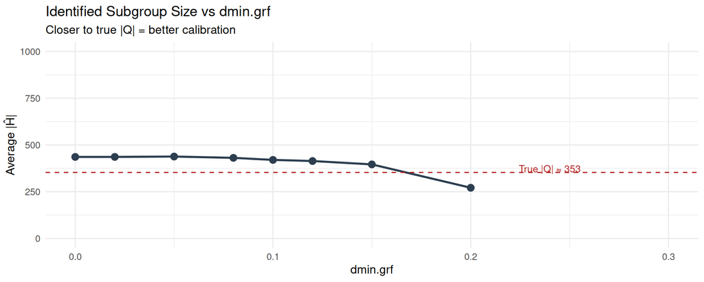

Average identified subgroup size under H1 as a function of dmin.grf.

```r
if (nrow(sweep_results) > 0) {
  true_Q_size <- round(sim_n * mean(actg_df$flag_harm_ref))

  ggplot(sweep_results, aes(x = dmin, y = Avg_nH_H1)) +
    geom_line(linewidth = 1, colour = "#2c3e50") +
    geom_point(size = 3, colour = "#2c3e50") +
    geom_hline(yintercept = true_Q_size, linetype = "dashed",
               colour = "firebrick") +
    annotate("text", x = max(dmin_grid) * 0.8, y = true_Q_size + 20,
             label = sprintf("True |Q| ≈ %d", true_Q_size),
             colour = "firebrick", size = 3.5) +
    labs(
      x = "dmin.grf",
      y = "Average |Ĥ|",
      title = "Identified Subgroup Size vs dmin.grf",
      subtitle = "Closer to true |Q| = better calibration"
    ) +
    coord_cartesian(ylim = c(0, sim_n)) +
    theme_minimal(base_size = 12)
}
```

## 5.5 Recommendation

```r
# Find the best dmin that meets targets
good <- sweep_results[sweep_results$Det_H1 >= target_det &
                        sweep_results$FPR_H0 <= target_fpr, ]

if (nrow(good) > 0) {
  best <- good[which.min(good$dmin), ]
  cat(sprintf(
    "**Recommended `dmin.grf = %.2f`** for the ACTG175 binary benefit scenario:\n\n",
    best$dmin))
  cat(sprintf("- Detection: %.0f%%\n", best$Det_H1))
  cat(sprintf("- FPR: %.0f%%\n", best$FPR_H0))
  cat(sprintf("- Sensitivity: %.2f\n", best$Sens_H1))
  cat(sprintf("- PPV: %.2f\n", best$PPV_H1))
  cat(sprintf("- Average |Ĥ|: %.0f (true |Q| ≈ %d)\n",
      best$Avg_nH_H1, round(sim_n * mean(actg_df$flag_harm_ref))))
} else {
  cat("**No `dmin.grf` value achieves both targets.**\n\n")

  # Find best tradeoff
  sweep_results$score <- sweep_results$Det_H1 - 2 * sweep_results$FPR_H0
  best_trade <- sweep_results[which.max(sweep_results$score), ]
  cat(sprintf(
    "Best tradeoff: `dmin.grf = %.2f` (Det=%.0f%%, FPR=%.0f%%, Sens=%.2f, PPV=%.2f)\n\n",
    best_trade$dmin, best_trade$Det_H1, best_trade$FPR_H0,
    best_trade$Sens_H1, best_trade$PPV_H1))

  # Also show relaxed target
  relaxed <- sweep_results[sweep_results$Det_H1 >= target_det &
                             sweep_results$FPR_H0 <= 25, ]
  if (nrow(relaxed) > 0) {
    best_relaxed <- relaxed[which.min(relaxed$dmin), ]
    cat(sprintf(
      "With relaxed FPR target (≤ 25%%): `dmin.grf = %.2f` (Det=%.0f%%, FPR=%.0f%%)\n",
      best_relaxed$dmin, best_relaxed$Det_H1, best_relaxed$FPR_H0))
  }
}
```

**No `dmin.grf` value achieves both targets.**

Best tradeoff: `dmin.grf = 0.12` (Det=54%, FPR=20%, Sens=0.94, PPV=0.78)

With relaxed FPR target (≤ 25%): `dmin.grf = 0.12` (Det=54%, FPR=20%)

# 6 Comparison with 4-Confounder Calibration

The synthetic 4-confounder calibration (`grf_dmin_calibration_binary.qmd`) found `dmin.grf = 0.02` sufficient for FPR $\leq 9\%$. The difference here reflects:

- **12 vs 4 confounders**: more candidate splits = higher multiplicity for the policy tree
- **Correlated confounders**: ACTG175 covariates have real correlations (e.g., CD4/CD8, age/Karnofsky) that create redundant splits
- **Imbalanced prevalence**: some z-variables have very asymmetric marginal distributions

# 7 Timing

```r
elapsed <- (proc.time() - t_start)["elapsed"]
cat(sprintf("Total render time: %.1f minutes (%.0f seconds)\n",
    elapsed / 60, elapsed))
```

```
#> Total render time: 5.2 minutes (310 seconds)
```

```r
cat(sprintf("Configuration: %d sims × %d dmin values × 2 hypotheses\n",
    nsims, length(dmin_grid)))
```

```
#> Configuration: 100 sims × 10 dmin values × 2 hypotheses
```

```r
cat(sprintf("Total GRF calls: ~%d\n",
    2 * nsims * length(dmin_grid)))
```

```
#> Total GRF calls: ~2000
```